# DTSC_5301_Final_Project_Report

## **Impact of Data Science in Food Industry**

**Team Members**:

Rohith Reddy Peddi  
Abhishict Pamula  
Bhuvanendra Putchala  
Sai Srinivasa S P  
Sai Gowtham Dasappa Ravindra  
Venkata Sairam Yanamandra

**Introduction**

The global population is projected to reach 10 billion by 2050, the demand for higher yields of nutritious food is set to rise significantly. To address various societal challenges, including an aging population, the impact of climate change, and limited resource availability, there is a growing need for innovative technologies in the food industry that can enhance the productivity and customer requirements of the food chain.

AI (Artificial Intelligence) and Data Science are experiencing significant growth in the food industry, and they are helping in various ways to improve efficiency, quality, and consumer experience. Here's how AI and Data Science are making an impact:

**Predictive Analytics**: Data science is used to analyze historical data and predict future trends in food consumption, allowing companies to make informed decisions about production, inventory management, and demand forecasting. This reduces waste and ensures products are available when consumers want them.

**Food Delivery Services**: The food delivery industry has seen significant growth, with AI algorithms helping platforms optimize delivery routes and provide better recommendations to customers. During the COVID-19 pandemic, food delivery services saw substantial increases in demand.

**Quality Control**: AI-powered image recognition and machine learning models are used for quality control. Cameras and sensors can detect defects, contaminants, or inconsistencies in food products during the production process, ensuring that only high-quality items reach consumers.

**Supply Chain Optimization**: AI helps optimize the supply chain by monitoring and adjusting inventory levels, transportation routes, and production schedules in real-time. This results in reduced costs and improved delivery times.

**Restaurant Industry**: AI-driven solutions have been helping restaurants improve customer service and optimize operations. According to the National Restaurant Association, 72% of restaurant operators believe that technology, including AI, can enhance the guest experience.

**Personalized Marketing**: Data science is used to analyze consumer data and preferences, enabling personalized marketing campaigns. AI algorithms can recommend products and promotions to individual consumers based on their past behavior, increasing sales and customer satisfaction.

**Menu Optimization**: Restaurants and food service providers use AI to analyze customer data and preferences to optimize their menus. This can lead to better menu design, pricing strategies, and the creation of new dishes that resonate with customers.

**Customer Service**: Chatbots and virtual assistants powered by AI are used in customer service to handle inquiries, take orders, and provide information. This enhances the customer experience and reduces wait times.

Overall, AI and Data Science are playing a crucial role in the food industry by improving operations, enhancing product quality and safety, and delivering a more personalized and efficient experience to consumers. As technology continues to advance, we can expect even greater innovation and integration of AI and data-driven solutions in the food sector.

**Emerging Tech Startups and Companies in Food Industry**

[figure not shown]

Every stakeholder, starting with farmers, shippers and retailers, ending with restaurants and shops, must have relevant data on the product and its condition. It’s also urgent to see the full picture and act, according to the gathered data, as of high expenses rate. For example, the restaurant industry is estimated at $899 billion in 2020 in the USA.

**Statement of the Question of Interest**:

1. **What is the average amount students are willing to spend when dining out?**
   - This question seeks to determine the typical budget allocation of students for dining at restaurants or eating out, providing insights into their spending habits.
2. **How frequently do students dine out, and does this vary based on their place of residence?**
   - This question explores the dining habits of students, considering the frequency of eating out and examining student interest on campus cafeteria based on their residential location.
3. **What are the favorite cuisines of students, and what does their ideal diet plan entail?**
   - This question aims to identify the culinary preferences of students by inquiring about their preferred cuisines. Additionally, it explores their aspirations for an ideal diet plan, offering insights into their dietary goals and preferences.
4. **Is there a relationship between the amount students are willing to pay when dining out and how often they eat out?**
   - This question investigates whether there is a correlation between students' budget preferences for dining out and the frequency of their dining-out experiences, providing a deeper understanding of their dining behavior.

**Data Description**

- Data was collected by Ms. Bora Pajo during her time as an assistant professor at Mercyhurst University in Erie, Pennsylvania.
- She surveyed 125 students regarding their food and eating choices. The survey includes 55 questions where the students self-reported their eating habits, food preferences and spending behavior.
- Columns Used for Analysis: '*Student Year*', '*Place of Residence*', '*How much are students willing to pay when they eat out*', '*How often do they eat out*', '*Ideal Diet according to them*' and '*Favourite Cuisine*'

Dataset: https://github.com/bora-pajo/Food/blob/master/food.csv

**Data Dictionary**

'*Describe your ideal diet in 2-3 sentences*': Responses describing the ideal diet plan.

'*What type of cuisine is your favorite?*': Favorite cuisine of respondents (e.g., Italian, Mexican).

'*What year are you?*': Academic year or level (e.g., Freshman, Sophomore).

'*Where do you live?*': Place of residence (e.g., On-campus housing, Off-campus apartment).

'*How much would you pay for a meal out?*': Amount respondents are willing to spend on a meal when dining out.

'*How often do you eat out of a week?*': Frequency of dining out in a typical week.

'*How likely are you to eat Thai, Indian, Italian, Persian & Greek food?*': Likelihood of eating specific cuisines, rated or described by respondents.

Let us start by importing the required libraries

```python
import pandas as pd
import numpy as np
import matplotlib.pyplot as plt
import seaborn as sns

import nltk
from nltk.corpus import stopwords
from wordcloud import WordCloud, STOPWORDS

sns.set_style()
pd.set_option('display.max_columns', None)
```

Dataset overview

```python
df = pd.read_csv('food.csv')
df.head(3)
```

|  | Please enter your email address (please enter the same email address you entered in the previous survey you took) | Approximately, how many days a week did your parents cook? | What is your favorite childhood food? (write up to three) | Was your favorite childhood food something your parents cooked or store bought? | What kind of food (cuisine) did you eat growing up? | How likely are you to eat fruits in any given day? | How likely are you to eat vegetables in any given day? | Describe your current diet in 2-3 sentences. | Describe your ideal diet in 2-3 sentences. | Describe any eating habit changes you have had since coming to college. | What are some of the reasons that make you eat comfort food? (i.e., anger, sadness, happiness, boredom, etc) - list up to three | List 3-5 comfort foods that come to mind. | What does a healthy meal look like? | Which of the two pictures shown below, comes to mind when you hear the word "coffee"? | Which of the two pictures shown below, comes to mind when you hear the word "drink"? | Which of the two pictures shown below, comes to mind when you hear the word "fries"? | Which of the two pictures shown below, comes to mind when you hear the word "soup"? | Which of the two pictures shown below, comes to mind when you hear the word "breakfast"? | How likely are you to try new or ethnic food? | How likely are you to eat Thai food? | How likely are you to eat Indian food? | How likely are you to eat Italian food? | How likely are you to eat Persian food? | How likely are you to eat Greek food? | What type of cuisine is your favorite? | Do you take any supplements or vitamins? | When purchasing food, how often do you check the nutritional value of the food? | How important is it that you consume the right amount of calories every day? | Can you guess how many calories are in the foods shown below? (starbucks cranberry orange scone) | … |
| --- | --- | --- | --- | --- | --- | --- | --- | --- | --- | --- | --- | --- | --- | --- | --- | --- | --- | --- | --- | --- | --- | --- | --- | --- | --- | --- | --- | --- | --- | --- |
| 0 | aalzak58@lakers.mercyhurst.edu | Almost Everyday | rice and chicken | something parents cooked at home | Arab's food the best | very likely | very likely | eat good and exercise | being healthy | eat faster | we dont have comfort | none | looks not oily | Option 1 | Option 1 | Option 2 | Option 1 | Option 1 | 1 | 1 | 5 | 5 | 5.0 | 5 | Arabic cuisine | Yes | on everything | I don't know how many calories I should consume | 315.0 | … |
| 1 | aartis56@lakers.mercyhurst.edu | Almost Everyday | chicken and biscuits, beef soup, baked beans | something parents cooked at home | American | likely | likely | I eat about three times a day with some snacks... | Try to eat 5-6 small meals a day. While trying... | I eat out more than usual. | Stress, bored, anger | chocolate, chips, ice cream | Grains, Veggies, (more of grains and veggies),... | Option 2 | Option 2 | Option 1 | Option 1 | Option 1 | 4 | 2 | 4 | 4 | 4.0 | 4 | Italian | No | on most products | It is moderately important | 420.0 | … |
| 2 | abonil22@lakers.mercyhurst.edu | Almost Everyday | mac and cheese, pizza, tacos | both store bought and home cooked | Mexican/Spanish | very likely | very likely | toast and fruit for breakfast, salad for lunch... | i would say my ideal diet is my current diet | sometimes choosing to eat fast food instead of... | stress, sadness | frozen yogurt, pizza, fast food | usually includes natural ingredients; nonproce... | Option 2 | Option 1 | Option 1 | Option 1 | Option 1 | 5 | 5 | 5 | 5 | 5.0 | 5 | italian | Yes | on most products | It is very important | 420.0 | … |

```python
df.shape
```

```
(125, 55)
```

Observations: The dataframe has 125 rows and 55 columns, Data in each row corresponds to the survey answers given by a student.

**Data Processing**

```python
columns_to_select = ['What year are you?',
                      'Where do you live?',
                      'How much would you pay for a meal out?',
                      'How often do you eat out of a week? - if you eat in cafeteria everyday, then answer how often do you eat out of cafeteria out of a week?',
                      'What type of cuisine is your favorite?',
                      'Describe your ideal diet in 2-3 sentences. ',
                      'How likely are you to eat Thai food?',
                      'How likely are you to eat Indian food?',
                      'How likely are you to eat Italian food?',
                      'How likely are you to eat Persian food?',
                      'How likely are you to eat Greek food?']

df_survey = df[columns_to_select]
df_survey.head(3)
```

|  | What year are you? | Where do you live? | How much would you pay for a meal out? | How often do you eat out of a week? - if you eat in cafeteria everyday, then answer how often do you eat out of cafeteria out of a week? | What type of cuisine is your favorite? | Describe your ideal diet in 2-3 sentences. | How likely are you to eat Thai food? | How likely are you to eat Indian food? | How likely are you to eat Italian food? | How likely are you to eat Persian food? | How likely are you to eat Greek food? |
| --- | --- | --- | --- | --- | --- | --- | --- | --- | --- | --- | --- |
| 0 | Sophomore | On campus | $5.01 to $10.00 | 2-3 times | Arabic cuisine | being healthy | 1 | 5 | 5 | 5.0 | 5 |
| 1 | Senior | On campus | $20.01 to $30.00 | 1-2 times | Italian | Try to eat 5-6 small meals a day. While trying... | 2 | 4 | 4 | 4.0 | 4 |
| 2 | Junior | Rent out of campus | $10.01 to $20.00 | 1-2 times | italian | i would say my ideal diet is my current diet | 5 | 5 | 5 | 5.0 | 5 |

Renaming Columns

```python
column_name_map = {'What year are you?':'year',
                   'Where do you live?': 'residence',
                   'How much would you pay for a meal out?':'amount_willing_to_spend',
                   'How often do you eat out of a week? - if you eat in cafeteria everyday, then answer how often do you eat out of cafeteria out of a week?':'num_of_times_visit',
                   'What type of cuisine is your favorite?':'favorite_cusisine',
                   'Describe your ideal diet in 2-3 sentences. ':'ideal_diet',
                   'How likely are you to eat Thai food?':'thai_food_rating',
                  'How likely are you to eat Indian food?':'indian_food_rating',
                  'How likely are you to eat Italian food?':'italian_food_rating',
                  'How likely are you to eat Persian food?':'persian_food_rating',
                  'How likely are you to eat Greek food?':'greek_food_rating'}
df_survey = df_survey.rename(columns=column_name_map)
```

Distrubition of Students Across Years

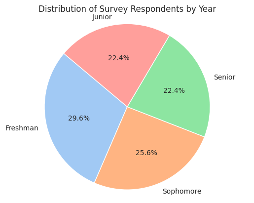

```python
year_counts = df_survey['year'].value_counts()

colors = sns.color_palette('pastel')[0:len(year_counts)]

plt.pie(year_counts, labels=year_counts.index, autopct='%1.1f%%', startangle=140, colors=colors)

plt.axis('equal')
plt.title('Distribution of Survey Respondents by Year')

plt.show()
```

Calculating Average Amount Each Student is Willing to Pay

```python
def avg_price(price_range):
  price_range = price_range.split(' to ')
  price_range = [float(item.split('$')[-1]) for item in price_range]
  return sum(price_range)/len(price_range)
```

```python
df_survey['average_pay'] = df_survey['amount_willing_to_spend'].apply(avg_price)
```

Histogram of Average Pay

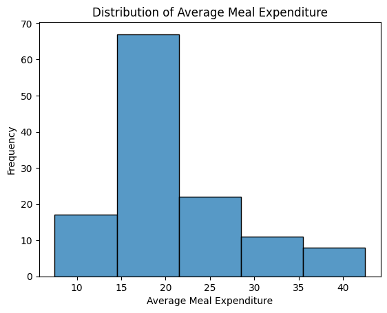

```python
sns.histplot(data=df_survey, x="average_pay", binwidth=7)
plt.xlabel('Average Meal Expenditure')
plt.ylabel('Frequency')
plt.title('Distribution of Average Meal Expenditure')
plt.show()
```

Observations: Most of the students are willing to pay 15-20 dollars when they go out to eat

Average Pay By Year

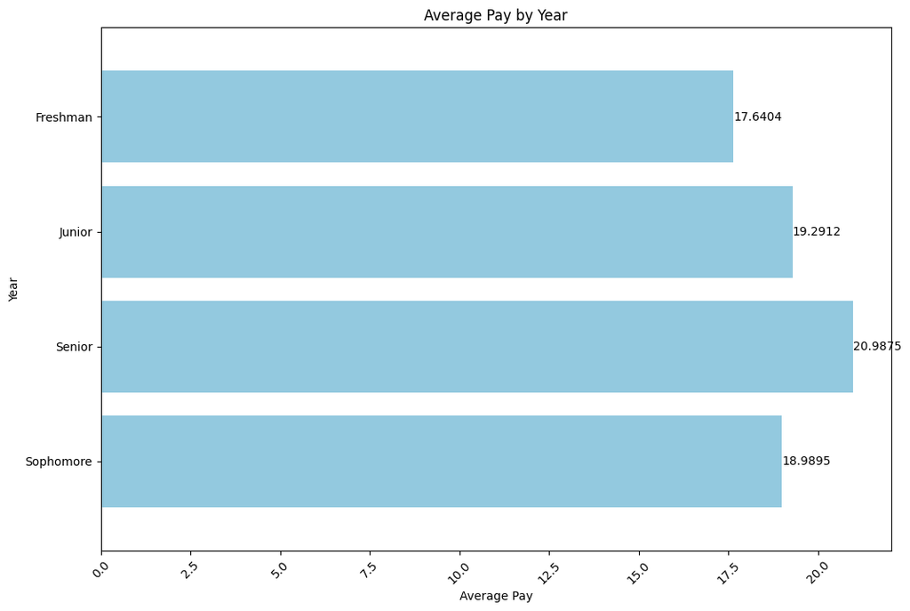

```python
fig, ax = plt.subplots(figsize=(12, 8))
sns.barplot(x=grouped_year_wise_pay['average_pay'], y=grouped_year_wise_pay['year'], ax=ax, color='skyblue')

# annotate
ax.bar_label(ax.containers[0], label_type='edge')
plt.ylabel('Year')
plt.xlabel('Average Pay')
plt.title('Average Pay by Year')
plt.xticks(rotation=45)

# pad the spacing between the number and the edge of the figure
ax.margins(y=0.1)
```

Student Year Vs Amount they are willing to Pay

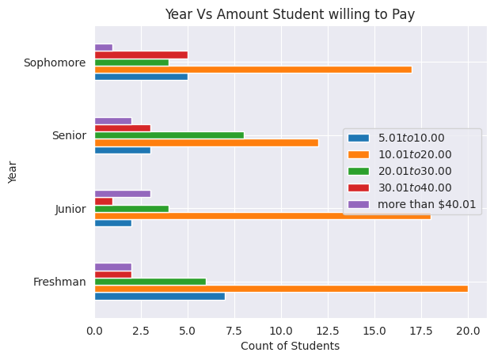

```python
df_year_wise_amount=pd.pivot_table(df_survey[['year','amount_willing_to_spend']],index = 'year'
         ,columns= 'amount_willing_to_spend',aggfunc=len)

sns.set_style('darkgrid')
df_year_wise_amount.plot(y=['$5.01 to $10.00','$10.01 to $20.00', '$20.01 to $30.00', '$30.01 to $40.00',
       'more than $40.01'],kind='barh')

plt.legend(loc='center right')
plt.ylabel('Year')
plt.xlabel('Count of Students')
plt.title('Year Vs Amount Student willing to Pay')
plt.show()
```

**Observations**: Based on the available data regarding students' food preferences, it's evident that a substantial portion of students is willing to allocate a budget of at least 10 to 20 dollars for dining out. Moreover, a noteworthy percentage of students are open to spending more than $20 on a meal. This presents a promising opportunity to capture substantial revenue within these spending brackets.

Place of Residence & How often do they go out to eat

```python
df_residence_freq_eatout = df_survey[['residence','num_of_times_visit']]
residence_freq_eatout=pd.pivot_table(df_residence_freq_eatout,
                    index = 'residence',columns='num_of_times_visit' ,aggfunc=len)
residence_freq_eatout = residence_freq_eatout.iloc[:-1]
residence_freq_eatout
```

| num_of_times_visit residence | 1-2 times | 2-3 times | 3-5 times | Never | every day |
| --- | --- | --- | --- | --- | --- |
| Live with my parents and commute | 6.0 | 2.0 | 1.0 | NaN | NaN |
| On campus | 44.0 | 20.0 | 9.0 | 14.0 | 10.0 |
| Own my own house | 1.0 | NaN | NaN | NaN | 1.0 |
| Rent out of campus | 9.0 | 2.0 | 3.0 | 1.0 | 1.0 |

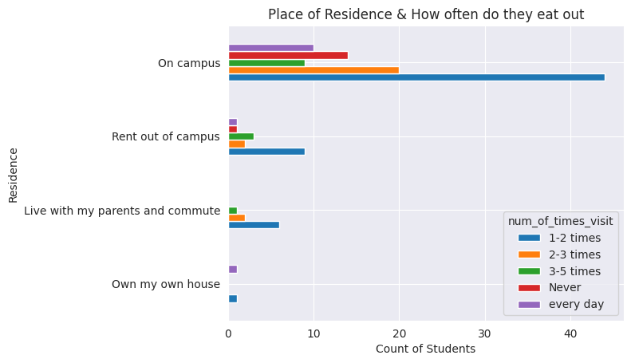

```python
sns.set_style('darkgrid')

residence_freq_eatout.sort_values(by=['1-2 times']).plot(y=residence_freq_eatout.columns,kind='barh')
plt.ylabel('Residence')
plt.xlabel('Count of Students')
plt.title('Place of Residence & How often do they eat out')
plt.show()
```

**Observations**: Analyzing their housing status, it's evident that a majority of students reside on campus. Simultaneously, when we examine their dining preferences in terms of how often they are willing to dine out, we observe a substantial number of students falling into the "1-2 times" category, with a noteworthy portion opting for "2 or more times." This observation suggests that a significant proportion of students are inclined towards frequent dining out, indicating a strong demand for dining opportunities outside their campus residences.

Percentage Distribution of Eating out & Amount they are willing to Spend

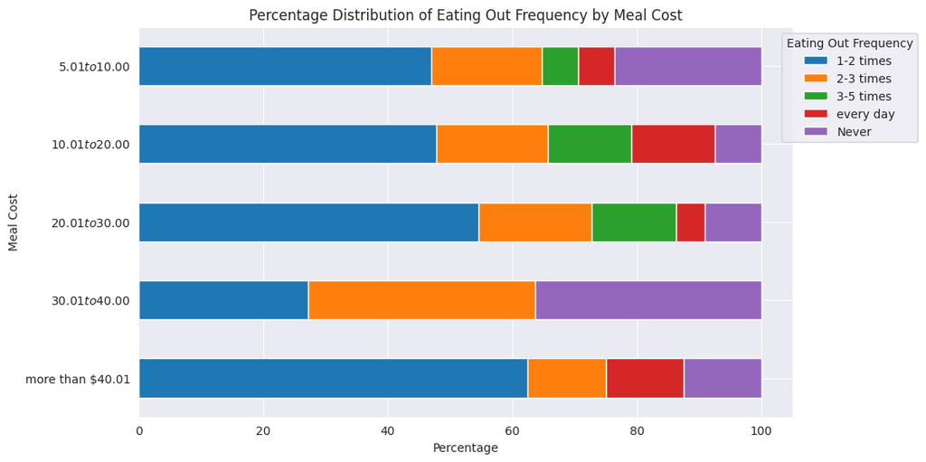

```python
amount_freq_eatout = df_survey[['amount_willing_to_spend','num_of_times_visit']]

amount_freq_eatout_pivot = pd.pivot_table(amount_freq_eatout,
                                          index='amount_willing_to_spend',
                                          columns='num_of_times_visit',
                                          aggfunc=len)

amount_freq_eatout_pivot = amount_freq_eatout_pivot.loc[['more than $40.01', '$30.01 to $40.00', '$20.01 to $30.00', '$10.01 to $20.00', '$5.01 to $10.00']]

total_count = amount_freq_eatout_pivot.sum(axis=1)

amount_freq_eatout_percentage = amount_freq_eatout_pivot.div(total_count, axis=0) * 100

ax = amount_freq_eatout_percentage[['1-2 times', '2-3 times', '3-5 times', 'every day', 'Never']].plot.barh(stacked=True, figsize=(10, 6))

plt.title('Percentage Distribution of Eating Out Frequency by Meal Cost')
plt.ylabel('Meal Cost')
plt.xlabel('Percentage')
plt.legend(title='Eating Out Frequency', loc='upper right', bbox_to_anchor=(1.2, 1))

plt.show()
```

**Observations**: In each price bracket, it's notable that a substantial percentage of individuals express their willingness to dine out either 1-2 times or 2-3 times. This presents a compelling revenue opportunity if we consider redesigning the campus dining menu and successfully attract a significant portion of the student population to dine on campus.

How likely are students to try different cuisines

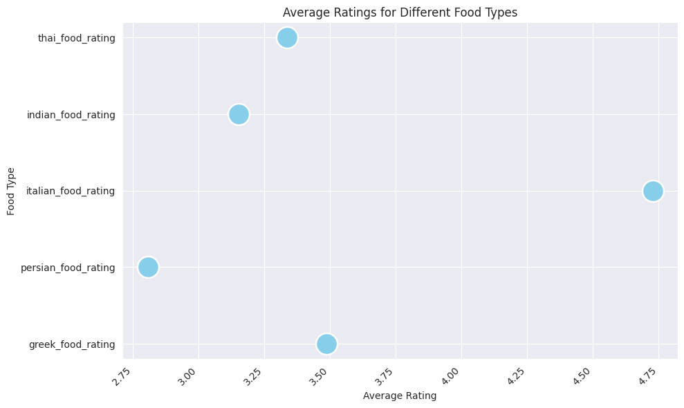

```python
food_columns = ['thai_food_rating',
       'indian_food_rating', 'italian_food_rating', 'persian_food_rating',
       'greek_food_rating']

average_ratings = df_survey[food_columns].mean()

df_average_ratings = pd.DataFrame({'Food Type': average_ratings.index, 'Average Rating': average_ratings.values})

sns.set_style('darkgrid')

plt.figure(figsize=(10, 6))
sns.scatterplot(data=df_average_ratings, y='Food Type', x='Average Rating', marker='o', s=500, color='skyblue')

plt.ylabel('Food Type')
plt.xlabel('Average Rating')
plt.title('Average Ratings for Different Food Types')
plt.xticks(rotation=45, ha='right')

plt.tight_layout()
plt.show()
```

Word Cloud of Student's Ideal Diet

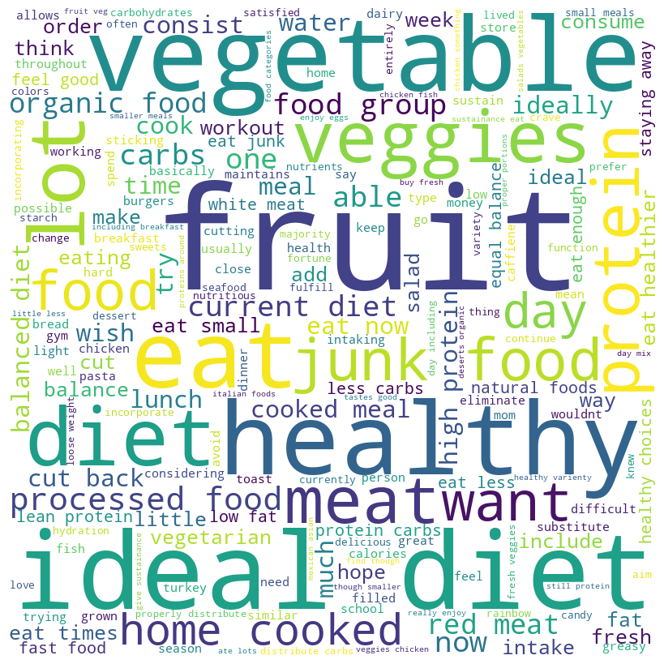

```python
ideal_diet = df_survey['ideal_diet'].values

comment_words = ' '
stopwords = set(STOPWORDS)

# iterate through the csv file
for val in ideal_diet:

  val = str(val)
  tokens = val.split()
  for i in range(len(tokens)):
    tokens[i] = tokens[i].lower()

  for words in tokens:
    comment_words = comment_words + words + ' '


wordcloud = WordCloud(width = 800, height = 800,
            background_color ='white',
            stopwords = stopwords,
            collocation_threshold = 3,
            min_font_size = 10).generate(comment_words)

# plot the WordCloud image
plt.figure(figsize = (8, 8), facecolor = None)
plt.imshow(wordcloud)
plt.axis("off")
plt.tight_layout(pad = 0)
```

**Observations**: By examining the keywords emphasized in their ideal diet descriptions, it becomes evident that students are inclined to add more vegetables and fruits into their diets. Building upon the insights gained from both the previous and current plots, we can leverage market basket analysis to craft meal platters that feature the ideal combination of students' favorite cuisines, alongside a well-balanced inclusion of vegetables and fruits.

**Conclusion**

Based on the available data, there are clear opportunities to enhance campus dining services:

- Budget Considerations: A significant portion of students is willing to spend between 10 and 20 dollars on a meal, with some open to higher spending. This presents an opportunity to introduce diverse dining options within these price ranges.
- On-Campus Residence: Most students reside on campus, indicating a convenient market for on-campus dining. Many students are also inclined to dine out frequently, further highlighting the demand for on-campus dining choices.
- Frequent Dining Out: A substantial number of students express a desire to dine out 1-2 times or more weekly, suggesting a strong demand for convenient and appealing dining options.
- Healthier Preferences: Students are interested in incorporating more vegetables and fruits into their diets. This presents an opportunity to promote healthier eating options.

To capitalize on these insights, campus dining services can revamp their menus to offer a variety of cuisines within the preferred price ranges, enhance on-campus dining experiences, and provide well-balanced meal options that include students' favorite cuisines alongside healthier components. This approach aligns with students' preferences, enhances nutritional value, and creates potential for increased revenue and improved customer satisfaction.

**Possible Sources of Bias**

While the data collected by Ms. Bora Pajo provides valuable insights, it's essential to acknowledge potential sources of bias that could affect the representativeness and generalizability of the findings. Here are possible sources of bias associated with this dataset:

1. **Sampling Bias**:
   - The sample consists of 125 students from Mercyhurst University. This may not be representative of the broader population and could introduce selection bias. The food preferences and spending behavior of college students might differ from those of the general population.
2. **Self-Reporting Bias**:
   - The data relies on self-reported information from students. Respondents may not always provide accurate or complete information about their eating habits and spending behavior, leading to reporting bias.
3. **Demographic Bias**:
   - The dataset might not adequately represent the diversity of student demographics. If certain groups of students are overrepresented or underrepresented, it can introduce bias.
4. **Small Sample Size**:
   - With only 125 respondents, the dataset's size is relatively small. This can limit the statistical power and precision of the analysis and may not fully capture the diversity of student preferences.

Understanding these potential sources of bias is crucial when interpreting the findings from this dataset and considering its relevance to broader populations or contexts.